# Problem Set 3 - Life History Theory

Mei Iwamoto

9/11/2024

Question 1 If you take the equation into two parts, the first half gY(t)N(t) refers to the yield of the fraction of germinating seeds. The second half of the equation (1-g)sN(t) refers to the number of the non-germinating seeds that survive to the next year. These seeds have two choices, they can grow and germinate and reproduce, adding more seeds to the bank, or stay dormant, which has some chance of surviving til next year. everyone that germinates dies.

g is the trait that we’re trying to optimize

Question 2

```r
#do a for loop, how do you incorporate the random flipping/environmental factor? every round of the loop, it needs to pick either good or bad at equal frequency
#use sample, look up ?sample
sample(c(4,0.1), size = 10, replace=T, prob=c(0.9,0.1))
```

```
##  [1] 4.0 0.1 4.0 4.0 4.0 4.0 4.0 0.1 4.0 0.1
```

```r
#for this question, we want equal frequency
sample(c(4,0.1), size = 100, replace=T, prob=c(0.5,0.5))
```

```
##   [1] 4.0 4.0 0.1 0.1 0.1 0.1 4.0 4.0 4.0 0.1 0.1 4.0 4.0 4.0 0.1 4.0 0.1 4.0
##  [19] 4.0 4.0 0.1 0.1 0.1 4.0 0.1 4.0 0.1 4.0 0.1 4.0 0.1 0.1 0.1 0.1 4.0 4.0
##  [37] 4.0 4.0 0.1 0.1 4.0 0.1 4.0 0.1 4.0 0.1 0.1 4.0 4.0 4.0 4.0 4.0 4.0 0.1
##  [55] 0.1 4.0 4.0 0.1 0.1 4.0 4.0 0.1 0.1 0.1 0.1 0.1 4.0 4.0 0.1 0.1 4.0 0.1
##  [73] 4.0 4.0 4.0 0.1 4.0 4.0 4.0 0.1 0.1 0.1 0.1 4.0 4.0 4.0 0.1 0.1 4.0 0.1
##  [91] 4.0 0.1 0.1 4.0 0.1 0.1 0.1 4.0 4.0 4.0
```

```r
sample<-vector()
sample<- sample(c(4,0.1), size = 100, replace=T, prob=c(0.5,0.5))

print(sample)
```

```
##   [1] 0.1 0.1 0.1 4.0 4.0 4.0 4.0 4.0 0.1 0.1 0.1 4.0 0.1 4.0 4.0 0.1 4.0 0.1
##  [19] 0.1 0.1 0.1 4.0 4.0 4.0 4.0 0.1 0.1 0.1 4.0 0.1 4.0 4.0 0.1 4.0 0.1 0.1
##  [37] 4.0 0.1 4.0 0.1 0.1 4.0 4.0 0.1 0.1 4.0 4.0 4.0 0.1 0.1 0.1 4.0 4.0 0.1
##  [55] 0.1 4.0 0.1 0.1 0.1 4.0 0.1 0.1 0.1 0.1 0.1 4.0 0.1 4.0 4.0 4.0 0.1 0.1
##  [73] 0.1 0.1 0.1 4.0 4.0 0.1 0.1 0.1 4.0 4.0 0.1 4.0 0.1 4.0 4.0 0.1 0.1 4.0
##  [91] 4.0 0.1 0.1 4.0 4.0 4.0 4.0 0.1 0.1 4.0
```

```r
sample[1]
```

```
## [1] 0.1
```

```r
#find a way to incorporate this into a for loop

N<-vector()
N[1]<-1
for(t in 1:100){ N[t+1] <- (0.5*sample[t]*N[t])+(0.5*0.9*N[t])
  }

print(N)
```

```
##   [1]   1.0000000   0.5000000   0.2500000   0.1250000   0.3062500   0.7503125
##   [7]   1.8382656   4.5037508  11.0341894   5.5170947   2.7585474   1.3792737
##  [13]   3.3792205   1.6896103   4.1395451  10.1418855   5.0709428  12.4238098
##  [19]   6.2119049   3.1059524   1.5529762   0.7764881   1.9023959   4.6608699
##  [25]  11.4191312  27.9768715  13.9884358   6.9942179   3.4971089   8.5679169
##  [31]   4.2839585  10.4956982  25.7144606  12.8572303  31.5002143  15.7501071
##  [37]   7.8750536  19.2938812   9.6469406  23.6350045  11.8175023   5.9087511
##  [43]  14.4764403  35.4672787  17.7336393   8.8668197  21.7237082  53.2230850
##  [49] 130.3965583  65.1982792  32.5991396  16.2995698  39.9339460  97.8381677
##  [55]  48.9190838  24.4595419  59.9258777  29.9629388  14.9814694   7.4907347
##  [61]  18.3523000   9.1761500   4.5880750   2.2940375   1.1470188   0.5735094
##  [67]   1.4050980   0.7025490   1.7212450   4.2170503  10.3317732   5.1658866
##  [73]   2.5829433   1.2914717   0.6457358   0.3228679   0.7910264   1.9380146
##  [79]   0.9690073   0.4845037   0.2422518   0.5935170   1.4541166   0.7270583
##  [85]   1.7812929   0.8906464   2.1820837   5.3461052   2.6730526   1.3365263
##  [91]   3.2744894   8.0224991   4.0112495   2.0056248   4.9137807  12.0387627
##  [97]  29.4949686  72.2626730  36.1313365  18.0656682  44.2608872
```

```r
#test for loop
0.5*4*1+0.5*0.9
```

```
## [1] 2.45
```

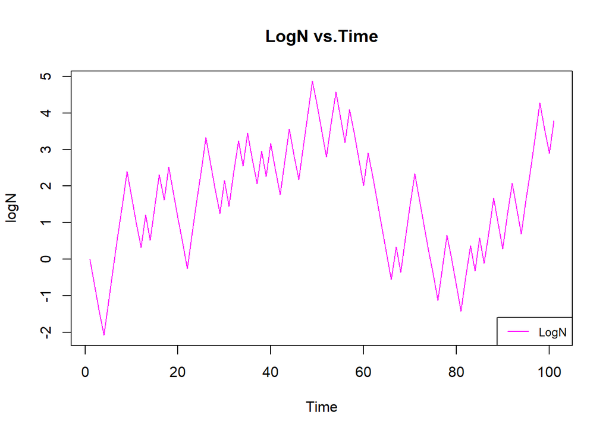

```r
plot(log(N, base=exp(1)), xlab='Time', ylab='logN', type='l', main='LogN vs.Time', col='magenta')
legend('bottomright', legend=c("LogN"), col=c('magenta'), lty=1, cex=0.8)
```

Question 3 N(t)*lambda, lambda = gY(t)+(1-g)s

Question 4

```r
#good year lambda
0.5*4+0.5*0.9
```

```
## [1] 2.45
```

```r
#bad year
0.5*0.1+0.5*0.9
```

```
## [1] 0.5
```

```r
#long term population growth rate = geometric mean
(2.45*0.5)^0.5
```

```
## [1] 1.106797
```

```r
#the population is growing because it's greater than 1
```

Question 5, g (0.2, 0.5, 0.7, 0.8)

```r
sample1<- sample(c(4,0.1), size = 1000, replace=T, prob=c(0.5,0.5))
sample2<- sample(c(4,0.1), size = 1000, replace=T, prob=c(0.5,0.5))
sample3<- sample(c(4,0.1), size = 1000, replace=T, prob=c(0.5,0.5))
sample4<- sample(c(4,0.1), size = 1000, replace=T, prob=c(0.5,0.5))
sample5<- sample(c(4,0.1), size = 1000, replace=T, prob=c(0.5,0.5))
sample6<- sample(c(4,0.1), size = 1000, replace=T, prob=c(0.5,0.5))
sample7<- sample(c(4,0.1), size = 1000, replace=T, prob=c(0.5,0.5))
sample8<- sample(c(4,0.1), size = 1000, replace=T, prob=c(0.5,0.5))
sample9<- sample(c(4,0.1), size = 1000, replace=T, prob=c(0.5,0.5))
sample10<- sample(c(4,0.1), size = 1000, replace=T, prob=c(0.5,0.5))

#could use replicate? each column is one sample?
ss <- vector()
ss <- replicate(10,sample(c(4,0.1), size = 1000, replace=T, prob=c(0.5,0.5)))
print(ss)
```

[output not shown]

[output cut: 986 more lines]

```r
print(ss[,1])
```

[output not shown]

[output cut: 41 more lines]

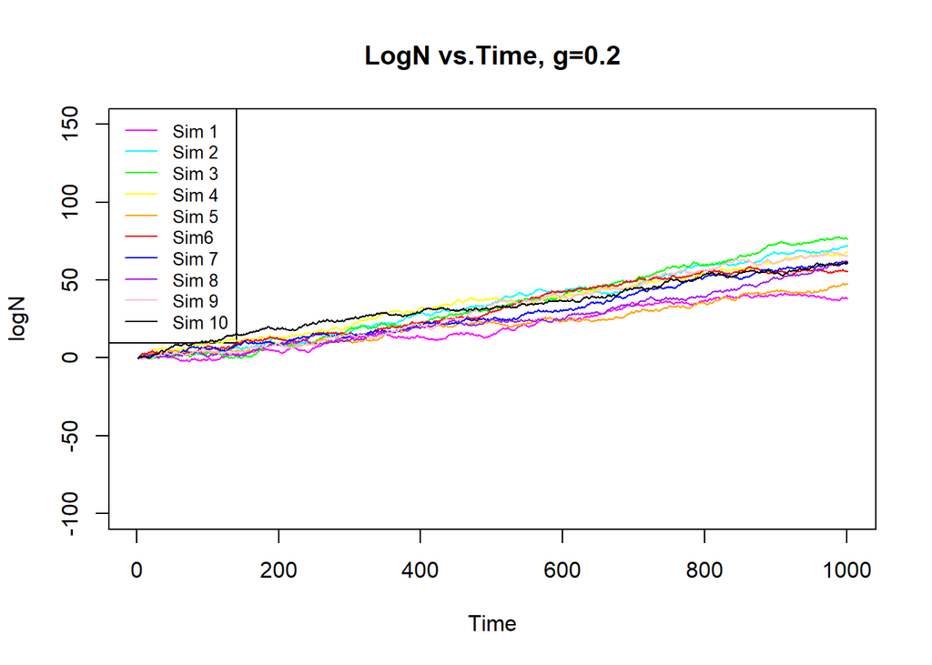

```r
#g=0.2
g1 <- vector()
g1[1] <-1
for (t in 1:1000) {g1[t+1] <- (0.2* sample1[t]*g1[t])+(0.8*0.9*g1[t])
}

g2<- vector()
g2[1] <-1
for (t in 1:1000) {g2[t+1] <- (0.2* sample2[t]*g2[t])+(0.8*0.9*g2[t])
}

g3<-vector()
g3[1]<-1
for (t in 1:1000) {g3[t+1]<-(0.2* sample3[t]*g3[t])+(0.8*0.9*g3[t])
}

g4<-vector()
g4[1]<-1
for (t in 1:1000) {g4[t+1]<-(0.2* sample4[t]*g4[t])+(0.8*0.9*g4[t])
}

g5<-vector()
g5[1]<-1
for (t in 1:1000) {g5[t+1]<-(0.2* sample5[t]*g5[t])+(0.8*0.9*g5[t])
}

g6<-vector()
g6[1]<-1
for (t in 1:1000) {g6[t+1]<-(0.2* sample6[t]*g6[t])+(0.8*0.9*g6[t])
}

g7<-vector()
g7[1]<-1
for (t in 1:1000) {g7[t+1]<-(0.2* sample7[t]*g7[t])+(0.8*0.9*g7[t])
}

g8<-vector()
g8[1]<-1
for (t in 1:1000) {g8[t+1]<-(0.2* sample8[t]*g8[t])+(0.8*0.9*g8[t])
}

g9<-vector()
g9[1]<-1
for (t in 1:1000) {g9[t+1]<-(0.2* sample9[t]*g9[t])+(0.8*0.9*g9[t])
}
g10<-vector()
g10[1]<-1
for (t in 1:1000) {g10[t+1]<-(0.2* sample10[t]*g10[t])+(0.8*0.9*g10[t])
}

plot(log(g1, base=exp(1)), xlab='Time', ylab='logN', type='l', main='LogN vs.Time, g=0.2', col='magenta', ylim = c(-100,150))
legend('topleft', legend=c("Sim 1","Sim 2","Sim 3","Sim 4","Sim 5", "Sim6", "Sim 7", "Sim 8", "Sim 9", "Sim 10" ), col=c('magenta', 'cyan', 'green','yellow','orange','red','blue','purple','pink','black'), lty=1, cex=0.8)
lines(log(g2, base=exp(1)), col='cyan')
lines(log(g3, base = exp(1)), col='green')
lines(log(g4, base = exp(1)), col='yellow')
lines(log(g5, base = exp(1)), col='orange')
lines(log(g6, base = exp(1)), col='red')
lines(log(g7, base = exp(1)), col='blue')
lines(log(g8, base = exp(1)), col='purple')
lines(log(g9, base = exp(1)), col='pink')
lines(log(g10, base = exp(1)), col='black')
```

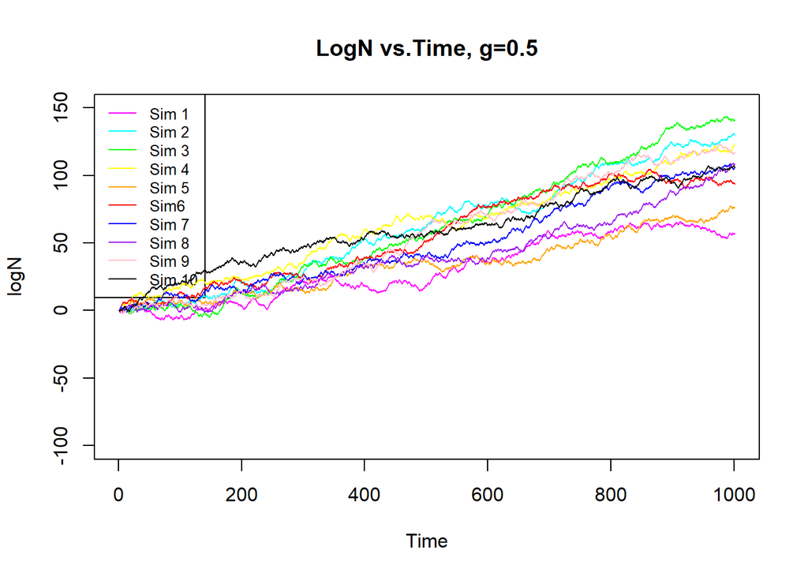

```r
#g=0.5
m1<-vector()
m1[1] <-1
for (t in 1:1000) {m1[t+1] <- (0.5* sample1[t]*m1[t])+(0.5*0.9*m1[t])
}

m2<- vector()
m2[1] <-1
for (t in 1:1000) {m2[t+1] <- (0.5* sample2[t]*m2[t])+(0.5*0.9*m2[t])
}

m3<-vector()
m3[1]<-1
for (t in 1:1000) {m3[t+1]<-(0.5* sample3[t]*m3[t])+(0.5*0.9*m3[t])
}

m4<-vector()
m4[1]<-1
for (t in 1:1000) {m4[t+1]<-(0.5* sample4[t]*m4[t])+(0.5*0.9*m4[t])
}

m5<-vector()
m5[1]<-1
for (t in 1:1000) {m5[t+1]<-(0.5* sample5[t]*m5[t])+(0.5*0.9*m5[t])
}

m6<-vector()
m6[1]<-1
for (t in 1:1000) {m6[t+1]<-(0.5* sample6[t]*m6[t])+(0.5*0.9*m6[t])
}

m7<-vector()
m7[1]<-1
for (t in 1:1000) {m7[t+1]<-(0.5* sample7[t]*m7[t])+(0.5*0.9*m7[t])
}

m8<-vector()
m8[1]<-1
for (t in 1:1000) {m8[t+1]<-(0.5* sample8[t]*m8[t])+(0.5*0.9*m8[t])
}

m9<-vector()
m9[1]<-1
for (t in 1:1000) {m9[t+1]<-(0.5* sample9[t]*m9[t])+(0.5*0.9*m9[t])
}
m10<-vector()
m10[1]<-1
for (t in 1:1000) {m10[t+1]<-(0.5* sample10[t]*m10[t])+(0.5*0.9*m10[t])
}

plot(log(m1, base=exp(1)), xlab='Time', ylab='logN', type='l', main='LogN vs.Time, g=0.5', col='magenta', ylim = c(-100,150))
legend('topleft', legend=c("Sim 1","Sim 2","Sim 3","Sim 4","Sim 5", "Sim6", "Sim 7", "Sim 8", "Sim 9", "Sim 10" ), col=c('magenta', 'cyan', 'green','yellow','orange','red','blue','purple','pink','black'), lty=1, cex=0.8)
lines(log(m2, base=exp(1)), col='cyan')
lines(log(m3, base = exp(1)), col='green')
lines(log(m4, base = exp(1)), col='yellow')
lines(log(m5, base = exp(1)), col='orange')
lines(log(m6, base = exp(1)), col='red')
lines(log(m7, base = exp(1)), col='blue')
lines(log(m8, base = exp(1)), col='purple')
lines(log(m9, base = exp(1)), col='pink')
lines(log(m10, base = exp(1)), col='black')
```

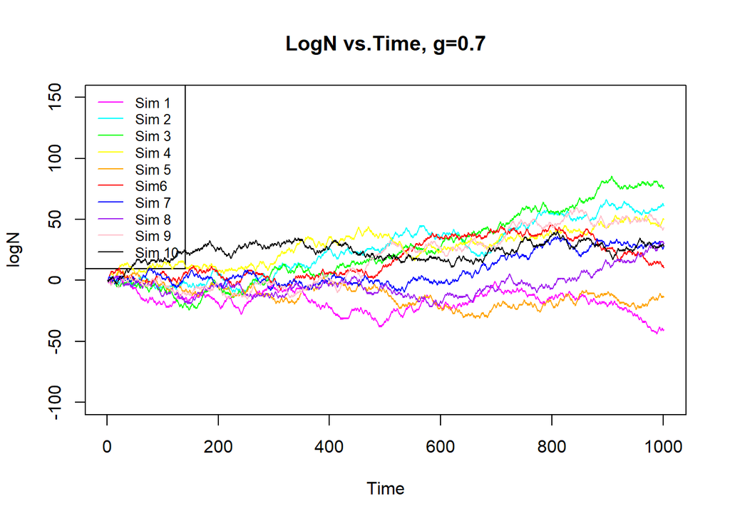

```r
#g=0.7
s1<-vector()
s1[1] <-1
for (t in 1:1000) {s1[t+1] <- (0.7* sample1[t]*s1[t])+(0.3*0.9*s1[t])
}

s2<- vector()
s2[1] <-1
for (t in 1:1000) {s2[t+1] <- (0.7* sample2[t]*s2[t])+(0.3*0.9*s2[t])
}

s3<-vector()
s3[1]<-1
for (t in 1:1000) {s3[t+1]<-(0.7* sample3[t]*s3[t])+(0.3*0.9*s3[t])
}

s4<-vector()
s4[1]<-1
for (t in 1:1000) {s4[t+1]<-(0.7* sample4[t]*s4[t])+(0.3*0.9*s4[t])
}

s5<-vector()
s5[1]<-1
for (t in 1:1000) {s5[t+1]<-(0.7* sample5[t]*s5[t])+(0.3*0.9*s5[t])
}

s6<-vector()
s6[1]<-1
for (t in 1:1000) {s6[t+1]<-(0.7* sample6[t]*s6[t])+(0.3*0.9*s6[t])
}

s7<-vector()
s7[1]<-1
for (t in 1:1000) {s7[t+1]<-(0.7* sample7[t]*s7[t])+(0.3*0.9*s7[t])
}

s8<-vector()
s8[1]<-1
for (t in 1:1000) {s8[t+1]<-(0.7* sample8[t]*s8[t])+(0.3*0.9*s8[t])
}

s9<-vector()
s9[1]<-1
for (t in 1:1000) {s9[t+1]<-(0.7* sample9[t]*s9[t])+(0.3*0.9*s9[t])
}
s10<-vector()
s10[1]<-1
for (t in 1:1000) {s10[t+1]<-(0.7* sample10[t]*s10[t])+(0.3*0.9*s10[t])
}

plot(log(s1, base=exp(1)), xlab='Time', ylab='logN', type='l', main='LogN vs.Time, g=0.7', col='magenta', ylim = c(-100,150))
legend('topleft', legend=c("Sim 1","Sim 2","Sim 3","Sim 4","Sim 5", "Sim6", "Sim 7", "Sim 8", "Sim 9", "Sim 10" ), col=c('magenta', 'cyan', 'green','yellow','orange','red','blue','purple','pink','black'), lty=1, cex=0.8)
lines(log(s2, base=exp(1)), col='cyan')
lines(log(s3, base = exp(1)), col='green')
lines(log(s4, base = exp(1)), col='yellow')
lines(log(s5, base = exp(1)), col='orange')
lines(log(s6, base = exp(1)), col='red')
lines(log(s7, base = exp(1)), col='blue')
lines(log(s8, base = exp(1)), col='purple')
lines(log(s9, base = exp(1)), col='pink')
lines(log(s10, base = exp(1)), col='black')
```

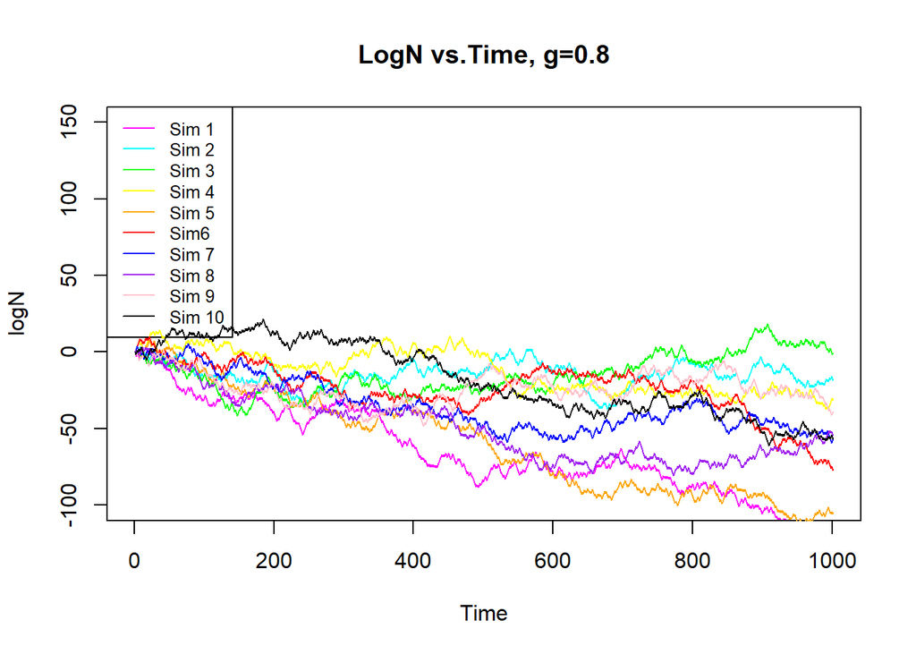

```r
#g=0.8
e1<-vector()
e1[1] <-1
for (t in 1:1000) {e1[t+1] <- (0.8* sample1[t]*e1[t])+(0.2*0.9*e1[t])
}

e2<- vector()
e2[1] <-1
for (t in 1:1000) {e2[t+1] <- (0.8* sample2[t]*e2[t])+(0.2*0.9*e2[t])
}

e3<-vector()
e3[1]<-1
for (t in 1:1000) {e3[t+1]<-(0.8* sample3[t]*e3[t])+(0.2*0.9*e3[t])
}

e4<-vector()
e4[1]<-1
for (t in 1:1000) {e4[t+1]<-(0.8* sample4[t]*e4[t])+(0.2*0.9*e4[t])
}

e5<-vector()
e5[1]<-1
for (t in 1:1000) {e5[t+1]<-(0.8* sample5[t]*e5[t])+(0.2*0.9*e5[t])
}

e6<-vector()
e6[1]<-1
for (t in 1:1000) {e6[t+1]<-(0.8* sample6[t]*e6[t])+(0.2*0.9*e6[t])
}

e7<-vector()
e7[1]<-1
for (t in 1:1000) {e7[t+1]<-(0.8* sample7[t]*e7[t])+(0.2*0.9*e7[t])
}

e8<-vector()
e8[1]<-1
for (t in 1:1000) {e8[t+1]<-(0.8* sample8[t]*e8[t])+(0.2*0.9*e8[t])
}

e9<-vector()
e9[1]<-1
for (t in 1:1000) {e9[t+1]<-(0.8* sample9[t]*e9[t])+(0.2*0.9*e9[t])
}
e10<-vector()
e10[1]<-1
for (t in 1:1000) {e10[t+1]<-(0.8* sample10[t]*e10[t])+(0.2*0.9*e10[t])
}

plot(log(e1, base=exp(1)), xlab='Time', ylab='logN', type='l', main='LogN vs.Time, g=0.8', col='magenta', ylim = c(-100,150))
legend('topleft', legend=c("Sim 1","Sim 2","Sim 3","Sim 4","Sim 5", "Sim6", "Sim 7", "Sim 8", "Sim 9", "Sim 10" ), col=c('magenta', 'cyan', 'green','yellow','orange','red','blue','purple','pink','black'), lty=1, cex=0.8)
lines(log(e2, base=exp(1)), col='cyan')
lines(log(e3, base = exp(1)), col='green')
lines(log(e4, base = exp(1)), col='yellow')
lines(log(e5, base = exp(1)), col='orange')
lines(log(e6, base = exp(1)), col='red')
lines(log(e7, base = exp(1)), col='blue')
lines(log(e8, base = exp(1)), col='purple')
lines(log(e9, base = exp(1)), col='pink')
lines(log(e10, base = exp(1)), col='black')
```

Question 6: use different values of g to determine long term growth rate and then plot it

```r
gg <-seq(0.1,1, by=0.1)
growth<- vector()
for (t in 1:10) {growth[t]<- (((gg[t]*4)+((1-gg[t])*0.9))*((gg[t]*0.1)+((1-gg[t])*0.9)))^0.5

}
print(growth)
```

```
##  [1] 0.9960924 1.0605659 1.0989995 1.1140916 1.1067972 1.0766615 1.0216653
##  [8] 0.9374433 0.8149847 0.6324555
```

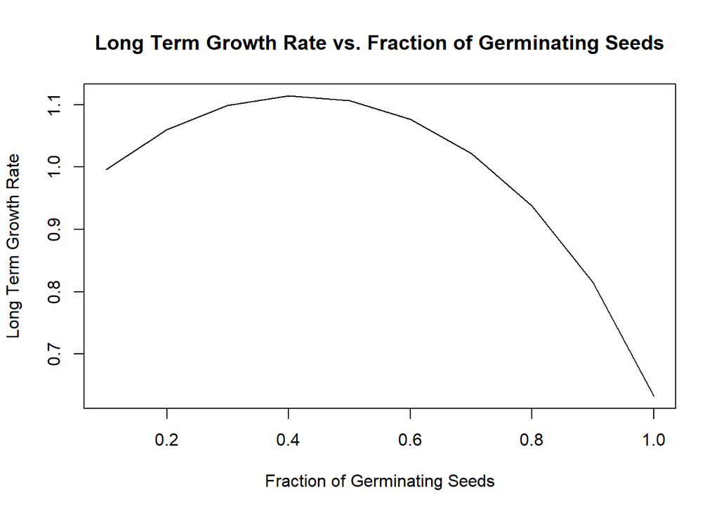

```r
plot(gg, growth, type = 'l', main = 'Long Term Growth Rate vs. Fraction of Germinating Seeds', ylab = 'Long Term Growth Rate', xlab='Fraction of Germinating Seeds')
```

```r
#Based off of this plot, the optimum value of g would be around 0.4 because that's where the long term growth rate is greatest.
```

Question 7: change something in question 2 and then get the different optimum, we can just plot question 6 for this new set of conditions instead of doing all 10 simulations again like in question 2

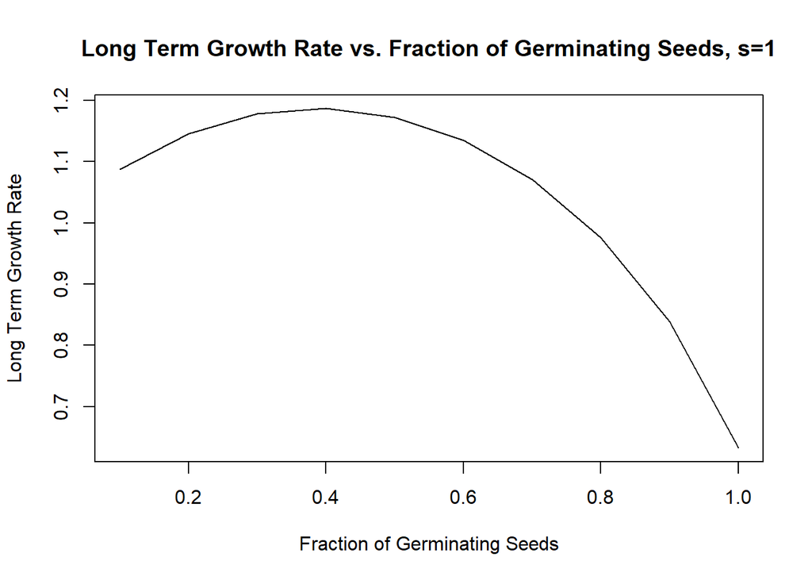

```r
#if s=1
diff<- vector()
for (t in 1:10) { diff[t] <- (((gg[t]*4)+ (1-gg[t]))*((gg[t]*0.1)+(1-gg[t])))^0.5

}
plot(gg, diff, type = 'l', main = 'Long Term Growth Rate vs. Fraction of Germinating Seeds, s=1', ylab='Long Term Growth Rate', xlab='Fraction of Germinating Seeds')
```

```r
#For this, I changed s, which was the fraction of non-germinating seeds that survive to next year, from 0.9 to 1. That change resulted in a slightly lower optimum value for g, but the plots do look pretty similar and it looks like it wasn't a dramatic change. It ended up slightly decreasing the optimum value for g because with s=1 now, it means there's no risk of mortality for any of the non-germinating seeds.
```